# lab4cp4

```r
knitr::opts_chunk$set(echo = TRUE)
# mylibs = c("readr", "dplyr", "ggplot2", "lubridate")
require(readr)
require(dplyr)
require(ggplot2)
require(plotly)
require(lubridate)
# install.packages("resample")
require(resample)
```

## Problema 4 - lab 04

Neste laboratório estaremos trabalhando o problema de amostragem. Nosso *dataset* é uma amostra de atividades no GitHub com a contagem de quantas pessoas editaram arquivos de determinadas linguagens de programação em cada dia de 2016 e início 2017. Como temos apenas uma amostra da população, utilizaremos a técnica de *bootstrap* para criar amostras tendo como base nossa amostra principal. Assim simulamos o que seria desejável realizar na prática, se possível, que seria a coleta de várias amostras para melhor representar uma população.

Para responder as questões do lab, iremos utilizar apenas um *subset*, focando nas linguagens **javascript** e **typescript**, por serem largamente usadas na comunidade e por serem relacionadas, podendo dizer que typescript seja uma evolução do javascript.

```r
github = read_csv(file = "../data/github-users-committing-filetypes.csv")
names(github)
```

```
## [1] "file_extension" "month_day"      "the_month"      "the_year"
## [5] "users"
```

```r
js_ts = github %>%
  filter(file_extension %in% c("js", "ts"))
```

## Breve EDA

### Como é a distribuição de users por linguagem?

```r
p = ggplot(js_ts, aes(x = file_extension, y = users)) +
  geom_boxplot(varwidth = TRUE)
ggplotly(p)
```

[interactive chart not shown]

Observamos que, de longe, a linguagem javascript tem maior atividade e diria que não temos *outiliers* estranhos ao contexto. Apenas dias que tiveram menos usuários fazendo edições quando comparados com a maioria, mas não fora do normal.

### Os meses de 2016 tem uma frequência de trabalho parecida?

```r
users_per_month_2016 = js_ts %>%
  filter(the_year == 2016) %>%
  group_by(file_extension, the_month) %>%
  summarise(total_users = sum(users))

p = users_per_month_2016 %>%
  ggplot(aes(x=as.factor(the_month), y=total_users, fill=file_extension)) +
  geom_bar(stat="identity", position=position_dodge()) +
  scale_x_discrete("Meses de 2016",
    breaks = c(1, 2, 3, 4, 5, 6, 7, 8, 9, 10, 11, 12),
    label = c("Jan", "Fev", "Mar", "Abr", "Maio", "Jun", "Jul", "Ago", "Set", "Out", "Nov", "Dez")) +
  scale_y_continuous("Total de usuários") +
  scale_fill_discrete("Linguagem")
ggplotly(p)
```

[interactive chart not shown]

Aqui confirma o boxplot visto anteriormente, com javascript liderando com maior número de usuários que editaram arquivos de sua linguagem. E podemos dizer que não temos um mês “diferentão” dos demais, mas aparentemente typescript apresenta uma variação menor entre os meses e teve um certo crescimento durante o ano.

### Como é a correlação entre os meses e número de usuários?

Correlação para javascript:

```r
users_per_month_2016_js = users_per_month_2016 %>% filter(file_extension == "js")
users_per_month_2016_js = users_per_month_2016_js[2:3]
show(cor(users_per_month_2016_js))
```

```
##             the_month total_users
## the_month    1.000000   -0.713148
## total_users -0.713148    1.000000
```

Para javascript temos uma correlação negativa(-0.713148), ou seja, o número de usuários cai ao passo que os meses aumentam. Mas não é uma correlação muito forte, então não podemos dizer que segue um padrão de queda bem definido ao longo de 2016.

```r
users_per_month_2016_ts = users_per_month_2016 %>% filter(file_extension == "ts")
users_per_month_2016_ts = users_per_month_2016_ts[2:3]
show(cor(users_per_month_2016_ts))
```

```
##             the_month total_users
## the_month   1.0000000   0.9327215
## total_users 0.9327215   1.0000000
```

Já para typescript tem uma forte correlação positiva(0.9327215), o que nos indica que realmente a “popularidade” dessa linguagem cresceu ao longo do ano de 2016 como suspeitávamos anteriormente. À medida que o número do mês cresceu o número de usuários também cresceu.

## Questões

### 1. Sobre o número de usuários de Javascript, existe diferença significativa entre a variação observada no primeiro trimestre de 2016 para com o primeiro trimestre de 2017?

Executaremos separadamente a técnica de bootstrap. Primeiro para o conjunto com informações do primeiro trimestre de 2016, depois para o primeiro trimestre de 2017. Queremos obter o intervalo de confiança para o desvio padrão desses dois trimestres e com isso calcular a diferença possível dessas variações.

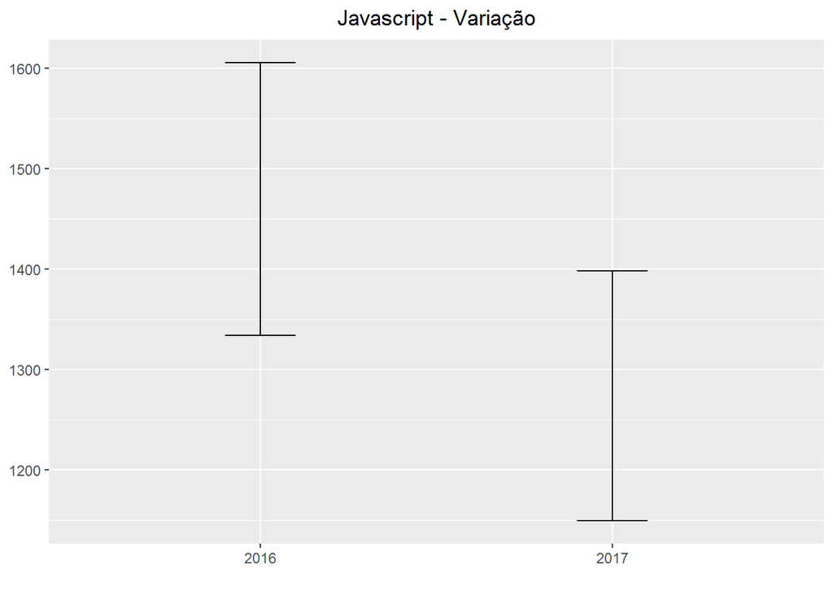

```r
js_begin_2016 = github %>%
  filter(file_extension == "js", the_month <= 3, the_year == 2016)
js_begin_2017 = github %>%
  filter(file_extension == "js", the_month <= 3, the_year == 2017)

js_2016_sd = bootstrap(data = js_begin_2016$users, statistic = sd)
js_2017_sd = bootstrap(data = js_begin_2017$users, statistic = sd)

js_2016_CI = CI.percentile(js_2016_sd, probs = c(.05, .95))
js_2017_CI = CI.percentile(js_2017_sd, probs = c(.05, .95))

data.frame(rbind(js_2016_CI, js_2017_CI)) %>%
  ggplot(aes(x = c("2016", "2017"), ymin = X5., ymax = X95.)) +
  geom_errorbar(width = .2) +
  ggtitle("Javascript - Variação") +
  theme(plot.title = element_text(hjust = 0.5)) +
  labs(x="")
```

Como temos uma interseção entre os dois intervalos nada podemos afirmar. A diferença entre as variações pode existir como também pode ser 0.

### 2. Javascript e Typescript cresceram ou diminuíram juntas observando os semestres de 2016?

##### Javascript

```r
js = github %>% filter(file_extension == "js")
js_2016 = js %>% filter(the_year == 2016)
js_2016 = js_2016 %>%
  mutate(semester = if_else(the_month <= 6, 1, 2))
```

Nesta primeira etapa usaremos bootstrap nos dados sobre **Javascript**, já que temos apenas uma amostra da população, a fim de analisar a quantidade de usuários que trabalharam com essa liguagem durante o primeiro e segundo semestre de 2016 e definirmos um intervalo para a estimativa da média para os semestres com 90% de confiança.

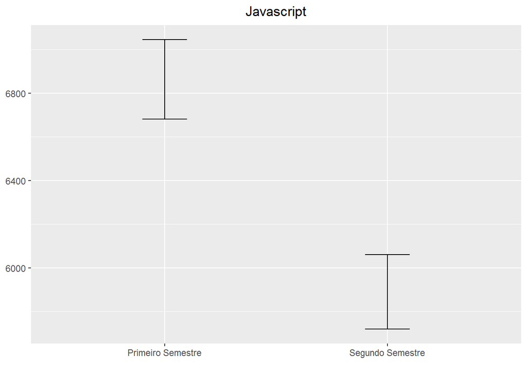

```r
# Javascript - bootstrap simples
js_first_sem = js_2016 %>% filter(semester == 1)
js_second_sem = js_2016 %>% filter(semester == 2)

js_first_sem_mean =  bootstrap(data = js_first_sem$users, statistic=mean)
js_second_sem_mean = bootstrap(data = js_second_sem$users, statistic = mean)

js_first_sem_CI = CI.percentile(js_first_sem_mean, probs = c(.05, .95))
js_second_sem_CI = CI.percentile(js_second_sem_mean, probs = c(.05, .95))

data.frame(rbind(js_first_sem_CI, js_second_sem_CI)) %>%
  ggplot(aes(x = c("Primeiro Semestre", "Segundo Semestre"), ymin = X5., ymax = X95.)) +
  geom_errorbar(width = .2) +
  ggtitle("Javascript") +
  theme(plot.title = element_text(hjust = 0.5)) +
  labs(x="")
```

Com o gráfico acima podemos entender que houve um decaimento no desenvolvimento usando javascript, comparando os semestres, tendo o segundo semestre uma média de usuários que alteraram arquivos *.js* menor que o primeiro semestre. Ainda utilizando a técnica de bootstrap, vamos agora estimar essa diferença entre os semestres.

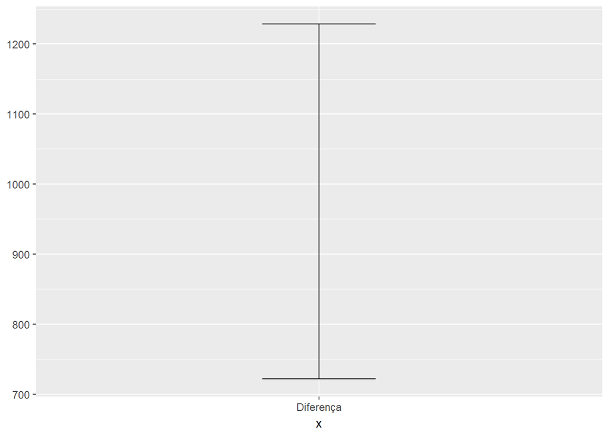

```r
# Bootstrap calculando a diferenca
b.diff.means = bootstrap2(js_2016$users,
                          mean,
                          treatment = js_2016$semester) # 10000 amostragens por padrão

means.diff = CI.percentile(b.diff.means, probs = c(.05, .95)) #confianca de 90%

data.frame(means.diff) %>%
  ggplot(aes(x = "Diferença", ymin = X5., ymax = X95.)) +
  geom_errorbar(width = .2)
```

```r
means.diff
```

```
##                 5%      95%
## mean: 1-2 721.9034 1228.211
```

##### Typescript

De maneira análoga a que usamos para estudar sobre javascript, agora vamos ver como se deu a evolução da linguagem **Typescript** comparando os semestres de 2016.

```r
ts = github %>% filter(file_extension == "ts")
ts_2016 = ts %>% filter(the_year == 2016)
ts_2016 = ts_2016 %>%
  mutate(semester = if_else(the_month <= 6, 1, 2))
```

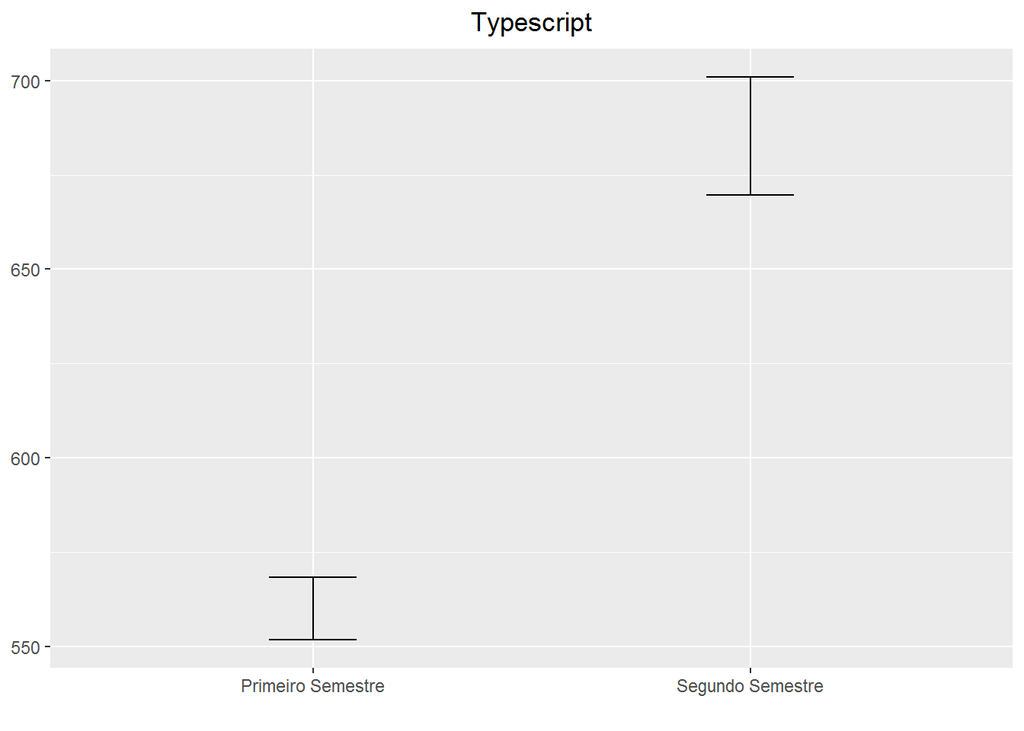

```r
# Typescript - bootstrap simples
ts_first_sem = ts_2016 %>% filter(semester == 1)
ts_second_sem = ts_2016 %>% filter(semester == 2)

ts_first_sem_mean =  bootstrap(data = ts_first_sem$users, statistic=mean)
ts_second_sem_mean = bootstrap(data = ts_second_sem$users, statistic = mean)

ts_first_sem_CI = CI.percentile(ts_first_sem_mean, probs = c(.05, .95))
ts_second_sem_CI = CI.percentile(ts_second_sem_mean, probs = c(.05, .95))

data.frame(rbind(ts_first_sem_CI, ts_second_sem_CI)) %>%
  ggplot(aes(x = c("Primeiro Semestre", "Segundo Semestre"), ymin = X5., ymax = X95.)) +
  geom_errorbar(width = .2) +
  ggtitle("Typescript") +
  theme(plot.title = element_text(hjust = 0.5)) +
  labs(x="")
```

Diferente de javascript, typescript obteve um crescimento do primeiro para o segundo semestre de 2016 no número de usuários que trabalharam com a linguagem. Vamos usar mais uma vez o bootstrap para estimar essa diferença entre os semestres.

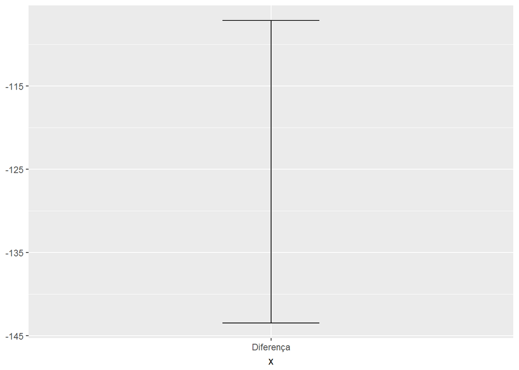

```r
# Bootstrap calculando a diferenca
b.diff.means = bootstrap2(ts_2016$users,
                          mean,
                          treatment = ts_2016$semester) # 10000 amostragens por padrão

means.diff = CI.percentile(b.diff.means, probs = c(.05, .95)) #confianca de 90%

data.frame(means.diff) %>%
  ggplot(aes(x = "Diferença", ymin = X5., ymax = X95.)) +
  geom_errorbar(width = .2)
```

```r
means.diff
```

```
##                  5%       95%
## mean: 1-2 -143.4881 -107.1683
```